# linc-Cox2 KO vs WT (Embryonic)

- other heatmap labels (csHeatmap)
- cache gsea and overlap figure!!
- tracks
- should import litter info

# Design Overview

This file shows the wt-v-ko comparison for linc-Cox2.

Cuff overview:

```
## CuffSet instance with:
##   2 samples
##   26754 genes
##   77524 isoforms
##   0 TSS
##   23066 CDS
##   0 promoters
##   0 splicing
##   19954 relCDS
```

# QC

```
## Error: 'from' cannot be NA, NaN or infinite
```

## Cross-replicate variability (fpkmSCVplot)

Differences in CV 2 can result in lower numbers of differentially expressed genes due to a higher degree of variability between replicate fpkm estimates.

Genes:

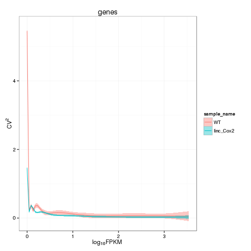

Isoforms:

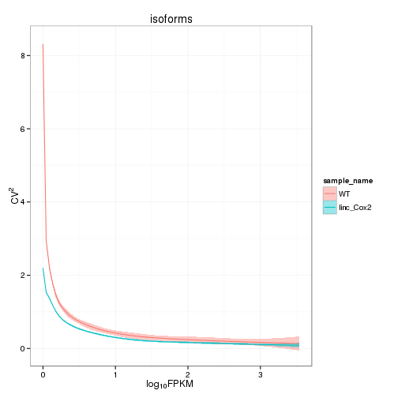

## Volcano

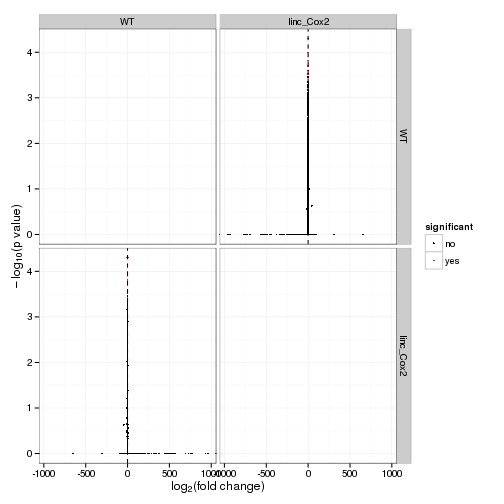

## Scatterplot

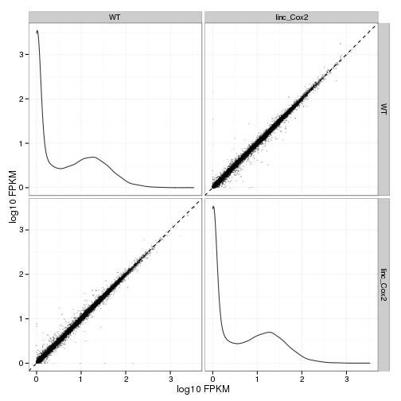

### Scatter matrix (replicates) – SKIP FOR NOW CAUSING PROBLEMS

## Distributions

### Boxplots

Boxplot (genes)

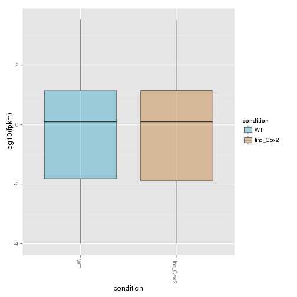

Boxplot (genes, replicates)

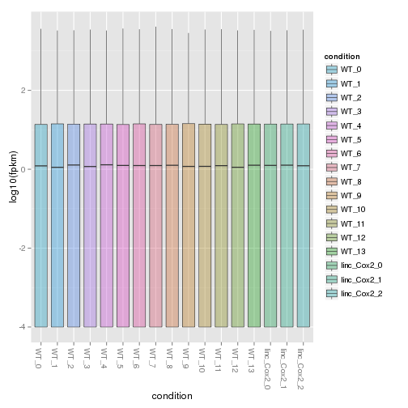

Boxplot (isoforms)

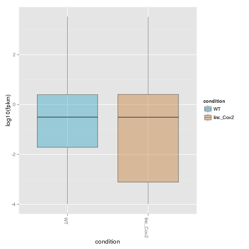

Boxplot (isoforms, replicates)

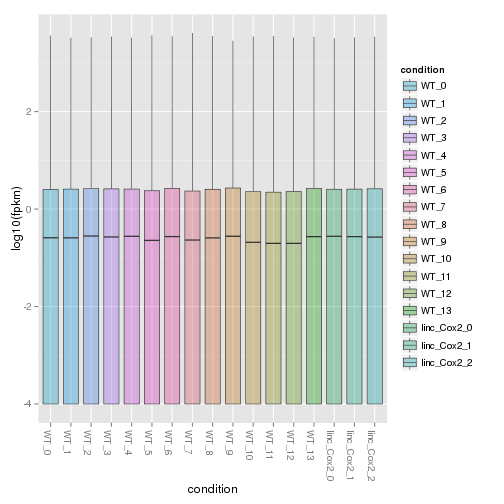

### Density

Density (genes)

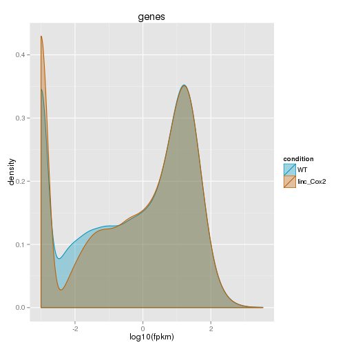

Density (genes, replicates)

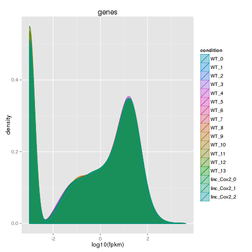

## Clustering

### Replicate Clusters

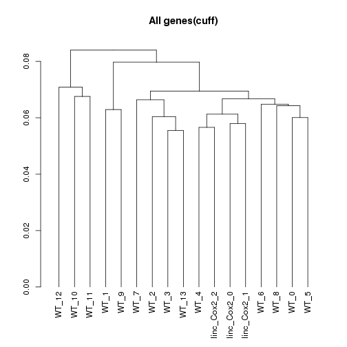

```
## 'dendrogram' with 2 branches and 17 members total, at height 0.08399
```

### PCA (genes)

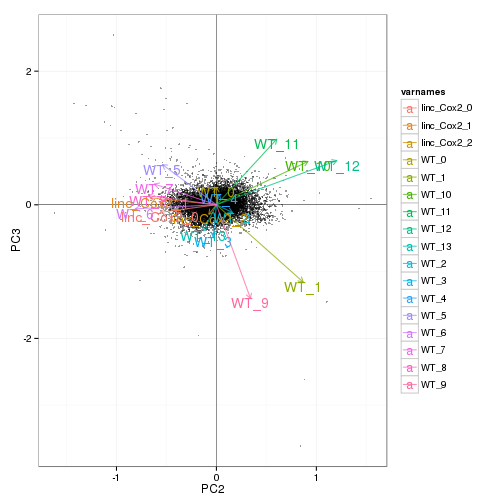

### MDS (genes)

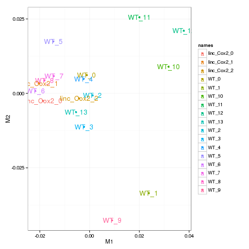

# KO assessment

## Endogenous lncRNA expression

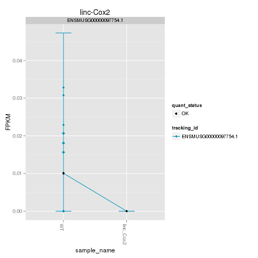

Endogenous expression of linc-Cox2 isoforms:

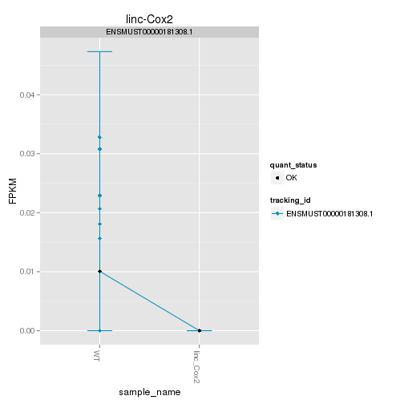

Barplot of gene expression:

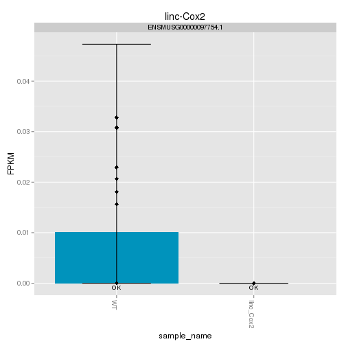

Barplot of isoform expression:

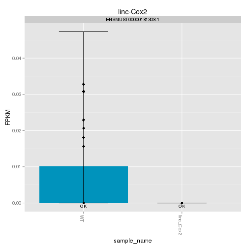

## LacZ expression

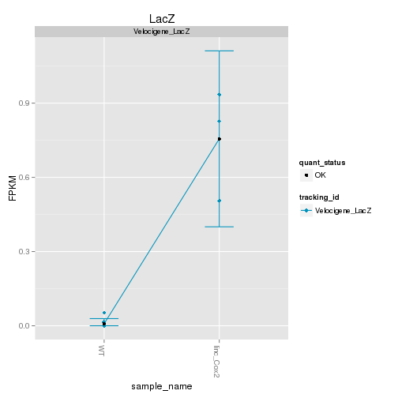

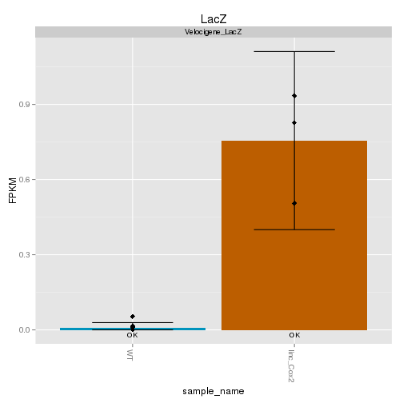

## Digital Genotyping (LacZ vs Endogenous lncRNA and Sex)

Expression plot (endogenous linc, lacZ, Y-expressed gene):

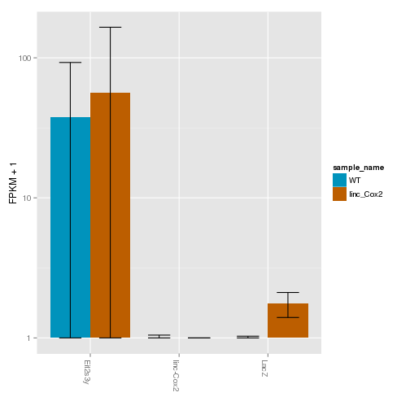

Expression heatmap:

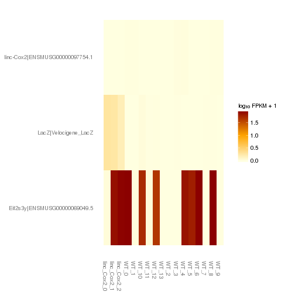

# Differential Analysis

## Differential Genes

There are 96 significantly differentially expressed genes. They are:

|  | geneAnnot$gene_short_name |
| --- | --- |
| 1 | Col1a1 |
| 2 | Rec8 |
| 3 | Zfp40 |
| 4 | Vax1 |
| 5 | Ttc9b |
| 6 | Lama2 |
| 7 | Snrpf |
| 8 | Skor1 |
| 9 | Dlx2 |
| 10 | Park2 |
| 11 | Glo1 |
| 12 | Prss41 |
| 13 | Atp6v0c |
| 14 | Hn1l |
| 15 | Lox |
| 16 | Fbn2 |
| 17 | Rps14 |
| 18 | Lbx1 |
| 19 | Col3a1 |
| 20 | Fn1 |
| 21 | Bok |
| 22 | Mcm6 |
| 23 | Dbi |
| 24 | Syt13 |
| 25 | Rps3a1 |
| 26 | Svep1 |
| 27 | Uncx |
| 28 | Emp1 |
| 29 | Dera |
| 30 | Hddc3 |

[output cut: 66 more lines]

### Matrix of gene significant differences between conditions

(skip for Brainmap wt-v-ko comparisons)

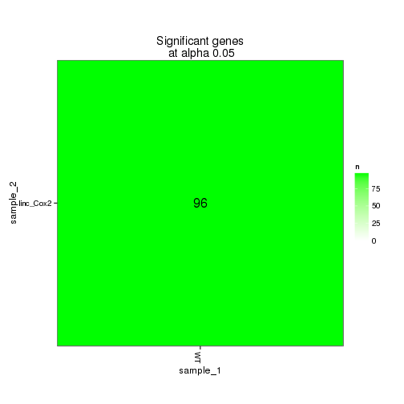

### Significant gene expression differences between conditions

Expression plot (genes):

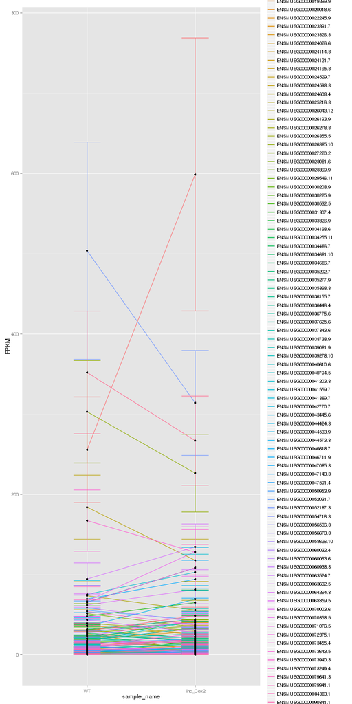

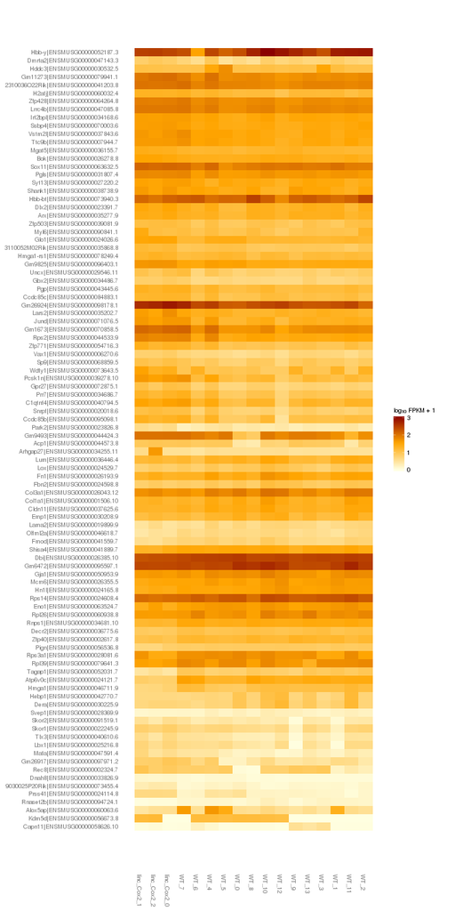

Significant genes with expression >50fpkm (any condition):

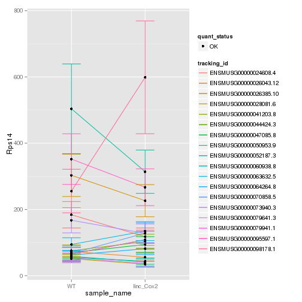

```
## Error: One or more values of 'x' or 'y' are not valid sample names!
```

```
## Error: One or more values of 'x' or 'y' are not valid sample names!
```

## Differential Splicing

### Differential Isoforms between conditions

Per isoform difference between conditions:

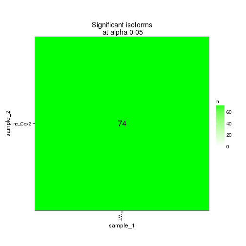

These isoforms are:

|  | isoAnnot$gene_short_name |
| --- | --- |
| 1 | Dynlt1c |
| 2 | Col1a1 |
| 3 | Rec8 |
| 4 | Zfp40 |
| 5 | Ttc9b |
| 6 | Lama2 |
| 7 | Snrpf |
| 8 | Prpf8 |
| 9 | Dlx2 |
| 10 | Hcfc1r1 |
| 11 | Glo1 |
| 12 | Atp6v0c |
| 13 | Hn1l |
| 14 | Lox |
| 15 | Fbn2 |
| 16 | Rps14 |
| 17 | Lbx1 |
| 18 | Fn1 |
| 19 | Asb1 |
| 20 | Mcm6 |
| 21 | Dbi |
| 22 | Lrp2 |
| 23 | Syt13 |
| 24 | Rps3a1 |
| 25 | Svep1 |
| 26 | Dera |
| 27 | Hddc3 |
| 28 | Rnf111 |
| 29 | Dnah8 |
| 30 | Gbx2 |
| 31 | Rnps1 |
| 32 | Fam171a2 |
| 33 | Prr7 |
| 34 | Lars2 |
| 35 | Arx |
| 36 | 3110052M02Rik |
| 37 | Decr2 |
| 38 | Cldn11 |
| 39 | Vstm2l |
| 40 | Pcsk1n |
| 41 | Dgkz |
| 42 | Tlx3 |
| 43 | C1qtnf4 |
| 44 | 2310036O22Rik |
| 45 | Fmod |
| 46 | Reln |
| 47 | Hebp1 |
| 48 | Pgp |
| 49 | Gm9493 |
| 50 | Zfp758 |
| 51 | Olfml2a |
| 52 | Hmga1 |
| 53 | Mafa |
| 54 | Col6a3 |
| 55 | Tagap1 |
| 56 | Hbb-y |
| 57 | Zfp771 |
| 58 | Pign |
| 59 | Kdm5d |
| 60 | Capn11 |
| 61 | Sox11 |
| 62 | Ssbp4 |
| 63 | Jund |
| 64 | Gpr27 |
| 65 | 9030025P20Rik |
| 66 | Gm11273 |
| 67 | Ccdc85c |
| 68 | Myl6 |
| 69 | Ccdc85b |
| 70 | Gm6472 |
| 71 | Gm9825 |
| 72 | Gm26917 |
| 73 | Gm26924 |

```
## Error: NaN dissimilarity value.
```

### Differential Splicing between conditions

(eval false for first pass)

# Gene/Pathway Analysis

## GSEA

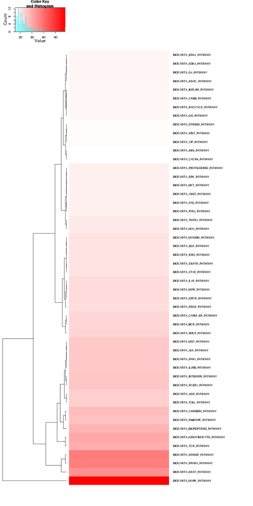

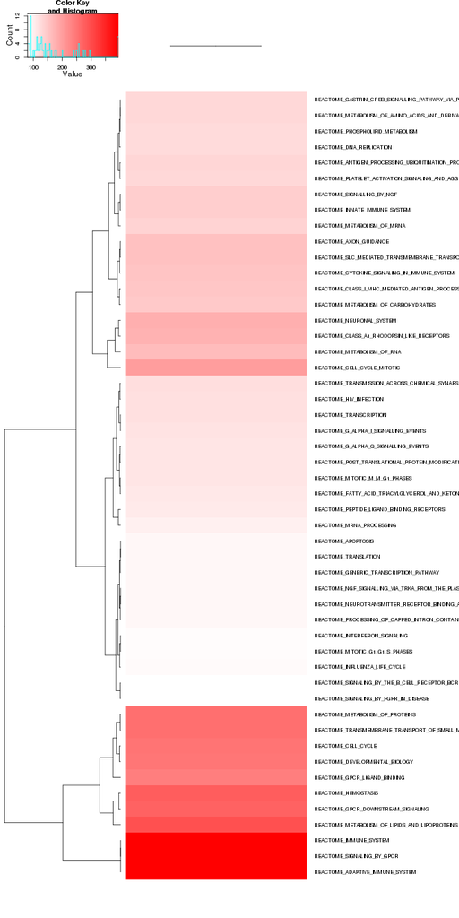

## GO enrichment

Cluster profiler used to call enichments of significantly differentially regulated genes that map to Entrez IDs.

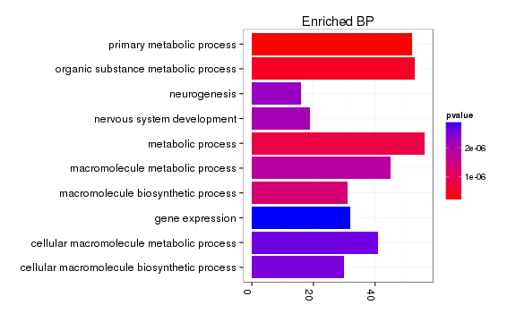

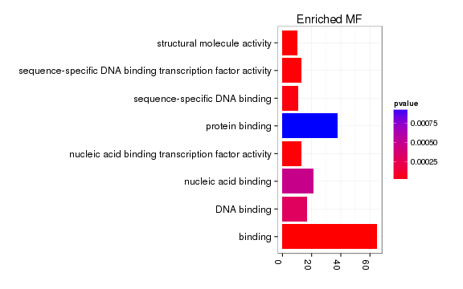

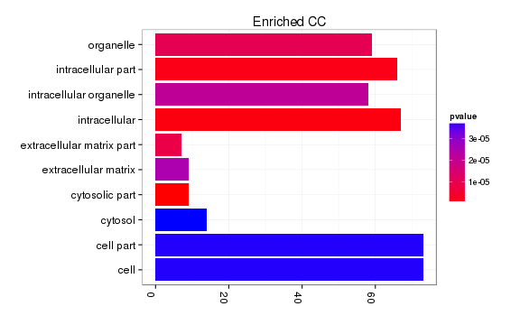

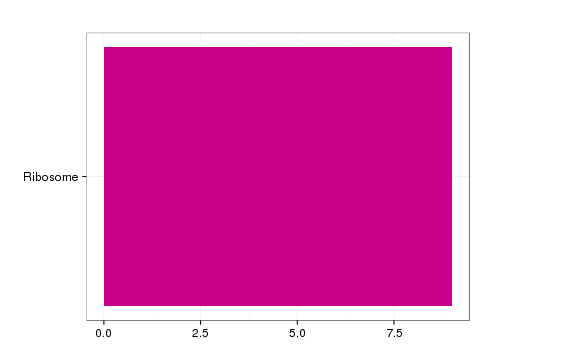

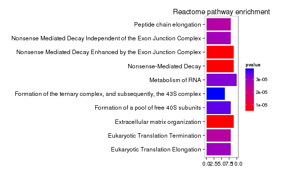

# Cis vs Trans (locally)

```
## Error: argument "seed" is missing, with no default
```

The pvalue for 0 genes significantly regulated in this region is: 1

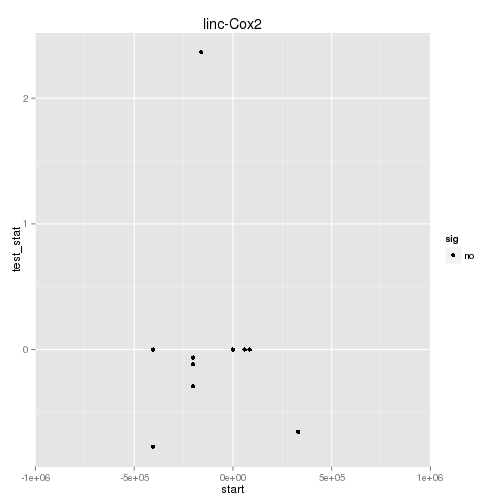

# Notes

## Samples used are:

|  | 10 |
| --- | --- |
| 1 | JR753 |
| 2 | JR750 |
| 3 | JR771 |
| 4 | JR755 |
| 5 | JR811 |
| 6 | JR768 |
| 7 | JR761 |
| 8 | JR815 |
| 9 | JR789 |
| 10 | JR748 |
| 11 | JR716 |
| 12 | JR717 |
| 13 | JR719 |
| 14 | JR756 |
| 15 | JR809 |
| 16 | JR816 |
| 17 | JR829 |

## Replicates

|  | file | sample_name | replicate | rep_name | total_mass | norm_mass | internal_scale | external_scale |
| --- | --- | --- | --- | --- | --- | --- | --- | --- |
| 1 | /n/rinn_data1/seq/lgoff/Projects/BrainMap/data/quants/JR753/abundances.cxb | WT | 0 | WT_0 | 39343800.00 | 32204800.00 | 1.27 | 1.00 |
| 2 | /n/rinn_data1/seq/lgoff/Projects/BrainMap/data/quants/JR750/abundances.cxb | WT | 1 | WT_1 | 36041100.00 | 32204800.00 | 1.10 | 1.00 |
| 3 | /n/rinn_data1/seq/lgoff/Projects/BrainMap/data/quants/JR771/abundances.cxb | WT | 2 | WT_2 | 38877000.00 | 32204800.00 | 1.23 | 1.00 |
| 4 | /n/rinn_data1/seq/lgoff/Projects/BrainMap/data/quants/JR755/abundances.cxb | WT | 3 | WT_3 | 41822800.00 | 32204800.00 | 1.29 | 1.00 |
| 5 | /n/rinn_data1/seq/lgoff/Projects/BrainMap/data/quants/JR811/abundances.cxb | WT | 4 | WT_4 | 38186700.00 | 32204800.00 | 1.21 | 1.00 |
| 6 | /n/rinn_data1/seq/lgoff/Projects/BrainMap/data/quants/JR768/abundances.cxb | WT | 5 | WT_5 | 28382500.00 | 32204800.00 | 0.90 | 1.00 |
| 7 | /n/rinn_data1/seq/lgoff/Projects/BrainMap/data/quants/JR761/abundances.cxb | WT | 6 | WT_6 | 31711800.00 | 32204800.00 | 0.98 | 1.00 |
| 8 | /n/rinn_data1/seq/lgoff/Projects/BrainMap/data/quants/JR815/abundances.cxb | WT | 7 | WT_7 | 29744300.00 | 32204800.00 | 0.93 | 1.00 |
| 9 | /n/rinn_data1/seq/lgoff/Projects/BrainMap/data/quants/JR789/abundances.cxb | WT | 8 | WT_8 | 27686600.00 | 32204800.00 | 0.86 | 1.00 |
| 10 | /n/rinn_data1/seq/lgoff/Projects/BrainMap/data/quants/JR748/abundances.cxb | WT | 9 | WT_9 | 32374600.00 | 32204800.00 | 0.96 | 1.00 |
| 11 | /n/rinn_data1/seq/lgoff/Projects/BrainMap/data/quants/JR716/abundances.cxb | WT | 10 | WT_10 | 26148700.00 | 32204800.00 | 0.81 | 1.00 |
| 12 | /n/rinn_data1/seq/lgoff/Projects/BrainMap/data/quants/JR717/abundances.cxb | WT | 11 | WT_11 | 25571500.00 | 32204800.00 | 0.80 | 1.00 |
| 13 | /n/rinn_data1/seq/lgoff/Projects/BrainMap/data/quants/JR719/abundances.cxb | WT | 12 | WT_12 | 22702200.00 | 32204800.00 | 0.69 | 1.00 |
| 14 | /n/rinn_data1/seq/lgoff/Projects/BrainMap/data/quants/JR756/abundances.cxb | WT | 13 | WT_13 | 38957200.00 | 32204800.00 | 1.22 | 1.00 |
| 15 | /n/rinn_data1/seq/lgoff/Projects/BrainMap/data/quants/JR809/abundances.cxb | linc_Cox2 | 0 | linc_Cox2_0 | 36059200.00 | 32204800.00 | 1.11 | 1.00 |
| 16 | /n/rinn_data1/seq/lgoff/Projects/BrainMap/data/quants/JR816/abundances.cxb | linc_Cox2 | 1 | linc_Cox2_1 | 31838500.00 | 32204800.00 | 0.98 | 1.00 |
| 17 | /n/rinn_data1/seq/lgoff/Projects/BrainMap/data/quants/JR829/abundances.cxb | linc_Cox2 | 2 | linc_Cox2_2 | 30840100.00 | 32204800.00 | 0.95 | 1.00 |

## Run Info

[output not shown]